# Boostrap Exercises

Mariana Chaves Espinoza

11/19/2020

```r
library(dplyr)
```

# Exercise 3

Let $X_1,...,X_n \sim t_3$ where $n = 25$. Let $\theta = T(F) = (q_{75} − q_{25})/1.34$ where $q_p$ denotes the pth quantile. Do a simulation to compare the coverage and length of the following confidence intervals for $\theta$: (i) Normal interval with standard error from the bootstrap, (ii) bootstrap percentile interval, and (iii) pivotal bootstrap interval.

## Simulation and puntual estimator

```r
#Data
N = 25
dat = rt(N, 3)

#Estimator
theta_hat = as.numeric((quantile(dat,0.75) - quantile(dat,0.25))/1.34)
theta_hat
```

```
## [1] 1.219503
```

### Bootstraping

```r
#Bootstrap
B = 1000
store_theta = vector(length = B)
for (i in 1:B){
  dat_ = sample(dat, replace = TRUE)
  store_theta[i]=(quantile(dat_,0.75) - quantile(dat_,0.25))/1.34
}
```

### Confidence intervals

```r
alpha = 0.05
```

#### Normal interval

$$T_n \pm z_{\alpha/2} \hat{se_{boot}}$$

```r
se=sd(store_theta)
z=qnorm(1 - alpha/2)
CI_norm = c(theta_hat-z*se, theta_hat+z*se)
CI_norm
```

```
## [1] 0.3653416 2.0736649
```

#### Pivotal interval

Let $\theta^*_\beta$ denote the $\beta$ sample quantile of $(\hat{\theta^*}_{n,1}...\hat{\theta^*}_{n,B})$

$$C_n = (2\hat{\theta_n}-\hat{\theta^*}_{1-\alpha/2} , 2\hat{\theta_n}-\hat{\theta^*}_{\alpha/2})$$

```r
theta_l=quantile(store_theta, 1 - alpha / 2) %>% as.numeric()
theta_u=quantile(store_theta, alpha / 2) %>%  as.numeric()
CI_pivotal=c(2*theta_hat-theta_l, 2*theta_hat-theta_u)
CI_pivotal
```

```
## [1] 0.5599329 2.0540962
```

#### Percentile quantile

$$C_n = (\theta^*_{\alpha/2},\theta^*_{1-\alpha/2})$$

```r
#Percentile interval
CI_percentile=quantile(store_theta,c(alpha/2,1-alpha/2)) %>% as.numeric()
CI_percentile
```

```
## [1] 0.3849103 1.8790736
```

### Coverage of the confidence intervals

```r
#Data
N = 25

theta_hat_2=c()
for (i in 1:1000) {
  dat = rt(N, 3)
  theta_hat_2[i] = as.numeric((quantile(dat,0.75) - quantile(dat,0.25))/1.34)
}

check_in_CI = function(x, CI){
  n_rep=length(x)
  return (sum(x>CI[1] & x<CI[2])/n_rep)

}

check_in_CI(theta_hat_2,CI_norm)
```

```
## [1] 0.997
```

```r
check_in_CI(theta_hat_2,CI_percentile)
```

```
## [1] 0.994
```

```r
check_in_CI(theta_hat_2,CI_pivotal)
```

```
## [1] 0.988
```

## Variation of the coverage

Now let’s see how the confidence intervals’ coverage changes given to the randomness of our sample.We can observe in 10 iterations how the coverage varies.

```r
coverage = c()
for (i in 1:10){
  #Data
  N = 25
  dat = rt(N, 3)

  #Estimator
  theta_hat = as.numeric((quantile(dat,0.75) - quantile(dat,0.25))/1.34)
  theta_hat

  #Bootstrap
  B = 1000
  store_theta = vector(length = B)
  for (i in 1:B){
    dat_ = sample(dat, replace = TRUE)
    store_theta[i]=(quantile(dat_,0.75) - quantile(dat_,0.25))/1.34
  }

  #Normal CI
  se=sd(store_theta)
  z=qnorm(1 - alpha/2)
  CI_norm = c(theta_hat-z*se, theta_hat+z*se)

  #Pivotal CI
  theta_l=quantile(store_theta, 1 - alpha / 2)
  theta_u=quantile(store_theta, alpha / 2)
  CI_pivotal=c(2*theta_hat-theta_l, 2*theta_hat-theta_u)

  #Percentile CI
  CI_percentile=quantile(store_theta,c(alpha/2,1-alpha/2))

  #Check coverage
  theta_hat_2=c()
  for (i in 1:1000) {
    dat = rt(N, 3)
    theta_hat_2[i] = as.numeric((quantile(dat,0.75) - quantile(dat,0.25))/1.34)
  }

  coverage = coverage %>% rbind(c(check_in_CI(theta_hat_2,CI_norm),
                                  check_in_CI(theta_hat_2,CI_pivotal),
                                  check_in_CI(theta_hat_2,CI_percentile)))

}

colnames(coverage) = c('Normal CI', 'Pivotal CI', 'Percentile CI')
coverage %>% as_tibble()
```

```
## # A tibble: 10 x 3
##    `Normal CI` `Pivotal CI` `Percentile CI`
##          <dbl>        <dbl>           <dbl>
##  1       0.861        0.748           0.935
##  2       0.847        0.837           0.845
##  3       0.849        0.861           0.862
##  4       0.839        0.748           0.881
##  5       0.956        0.883           0.984
##  6       0.479        0.382           0.723
##  7       0.954        0.447           0.994
##  8       0.772        0.403           0.877
##  9       0.982        0.935           0.879
## 10       0.838        0.838           0.866
```

## Coverage with increased sample size

Now we use a sample size of 1000 instead of 25, and we measure the coverage in 10 iterations.

```r
coverage = c()
for (i in 1:10){
  #Data
  N = 1000
  dat = rt(N, 3)

  #Estimator
  theta_hat = as.numeric((quantile(dat,0.75) - quantile(dat,0.25))/1.34)
  theta_hat

  #Bootstrap
  B = 1000
  store_theta = vector(length = B)
  for (i in 1:B){
    dat_ = sample(dat, replace = TRUE)
    store_theta[i]=(quantile(dat_,0.75) - quantile(dat_,0.25))/1.34
  }

  #Normal CI
  se=sd(store_theta)
  z=qnorm(1 - alpha/2)
  CI_norm = c(theta_hat-z*se, theta_hat+z*se)

  #Pivotal CI
  theta_l=quantile(store_theta, 1 - alpha / 2)
  theta_u=quantile(store_theta, alpha / 2)
  CI_pivotal=c(2*theta_hat-theta_l, 2*theta_hat-theta_u)

  #Percentile CI
  CI_percentile=quantile(store_theta,c(alpha/2,1-alpha/2))

  #Check coverage
  theta_hat_2=c()
  for (i in 1:1000) {
    dat = rt(N, 3)
    theta_hat_2[i] = as.numeric((quantile(dat,0.75) - quantile(dat,0.25))/1.34)
  }

  coverage = coverage %>% rbind(c(check_in_CI(theta_hat_2,CI_norm),
                                  check_in_CI(theta_hat_2,CI_pivotal),
                                  check_in_CI(theta_hat_2,CI_percentile)))

}

colnames(coverage) = c('Normal CI', 'Pivotal CI', 'Percentile CI')
coverage %>% as_tibble()
```

```
## # A tibble: 10 x 3
##    `Normal CI` `Pivotal CI` `Percentile CI`
##          <dbl>        <dbl>           <dbl>
##  1       0.878        0.888           0.854
##  2       0.736        0.813           0.72
##  3       0.863        0.807           0.905
##  4       0.933        0.954           0.905
##  5       0.957        0.967           0.935
##  6       0.816        0.858           0.775
##  7       0.756        0.711           0.776
##  8       0.897        0.947           0.852
##  9       0.904        0.921           0.899
## 10       0.868        0.878           0.884
```

# Exercise 6

Let $X_1, ...,X_n$ $Normal(\mu, 1)$. Let $\theta = e^{\mu}$ and let $\hat{\theta} = e^\bar{X}$. Create a data set (using $\mu = 5$) consisting of $n=100$ observations.

```r
#Data
N = 100
dat = rnorm(N, mean = 5, sd = 1)
```

## a

Use the bootstrap to get the se and 95 percent confidence interval for $\theta$.

```r
#Estimator
theta_hat = exp(mean(dat))

#Bootstrap
B = 1000
store_theta = vector(length = B)
for (i in 1:B){
  dat_ = sample(dat, replace = TRUE)
  store_theta[i]=exp(mean(dat_))
}

#Confidence interval
alpha = 0.05
z=qnorm(1 - alpha/2)
se=sd(store_theta)
c(theta_hat-z*se, theta_hat+z*se)
```

```
## [1] 114.1691 175.2120
```

## b

Plot a histogram of the bootstrap replications. This is an estimate of the distribution of $\hat{\theta}$. Compare this to the true sampling distribution of $\hat{\theta}$.

Due to the central limit theorem we can assume that $\bar{X}$ follows a normal distribution $\mu=5$ and $sd = 1/\sqrt{n} = 1/\sqrt{100}$. Therefore we can assume $e^{\bar{X}}$ follows a log-normal distribution with $\mu = 5$, $sd = 1/\sqrt{100}$

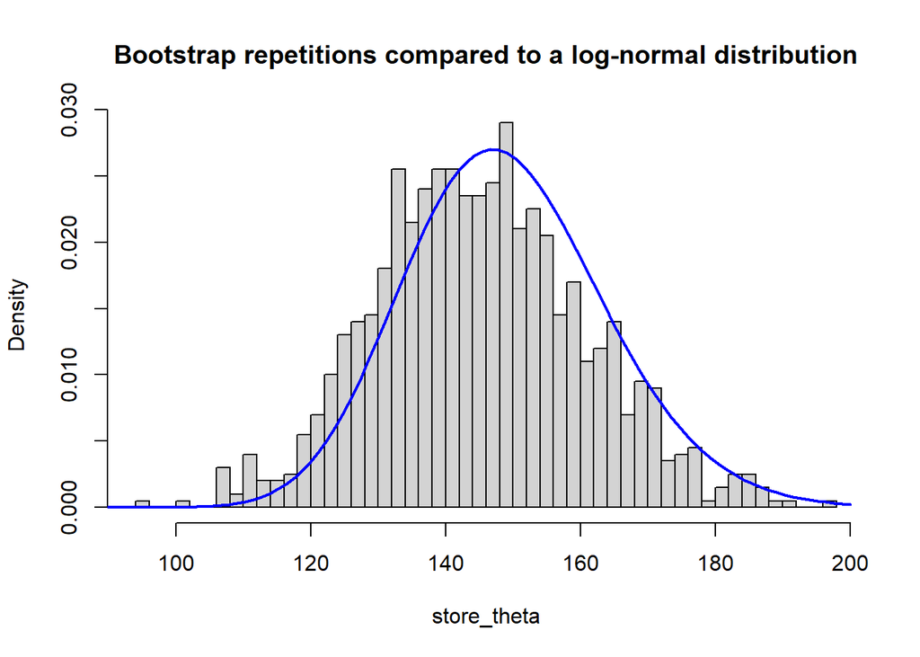

```r
x=seq(80,200,length=100)
y=dlnorm(x, mean=5, sd=1/sqrt(N))
hist(store_theta, freq = FALSE, main = "Bootstrap repetitions compared to a log-normal distribution", breaks = 50)
lines(x,y, col="blue", lwd=2)
```

## Bonus

Let’s see what happens when we use several repetitions of the data (NOT USING BOOTSTRAP REPETITIONS). In this case we can see that our estimator follows the expected distribution.

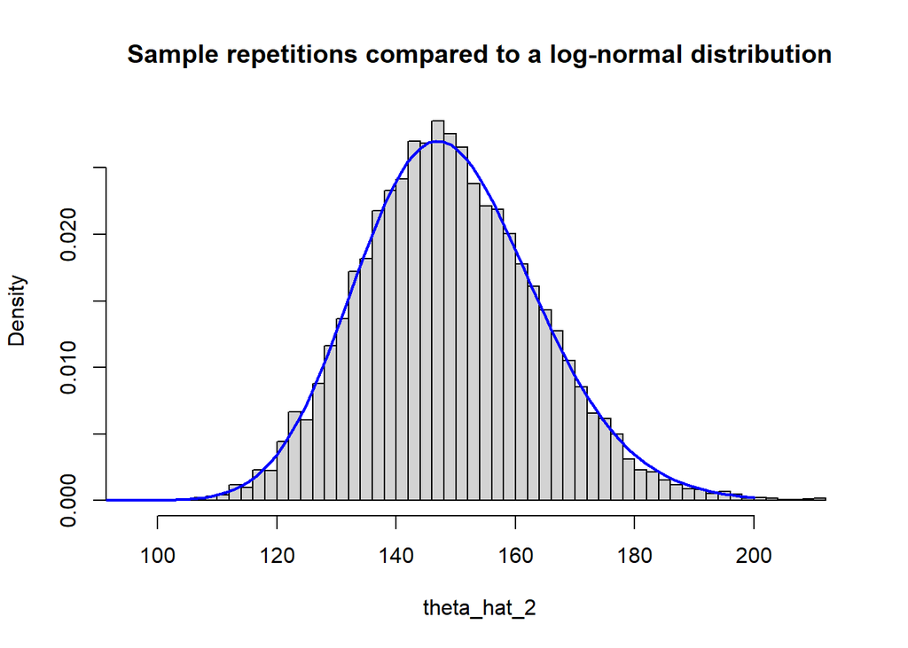

```r
N = 100
theta_hat_2=c()
for (i in 1:10000){
  dat = rnorm(N, mean = 5, sd = 1)
  theta_hat_2[i] = exp(mean(dat))
}

hist(theta_hat_2, freq = FALSE, main = "Sample repetitions compared to a log-normal distribution", breaks = 50)
lines(x,y, col="blue", lwd=2)
```

## Conclusion

Bootstrap confidence intervals can be quite off depending on the type of distribution of your data.